# Calculating Walking trips impedance function- 1986

# Active-transport walking and cycling behaviour in Canada

## Data and Method

Data on walking and cycling trips to different destinations was derived from Canada’s General Social Survey (GSS) from 1986 to 2015. GSS is a social trends survey in order to monitor changes in the living conditions and well-being of Canadians and to provide information on specific social policy issues. one of the important information of GSS is about Time-use surveys. This survey collects information on all human activities and can therefore inform a broad range of policies. Statistics Canada has been conducting time-use surveys since 1986 at approximately five- to seven- year intervals, most recently in 2015.The GSS on time use employs a retrospective 24-hour time diary to collect information on respondents’ participation in, and time spent on, a wide variety of day-to-day activities. In addition, information is collected on the location where these activities occurred (e.g., at home, at work, etc.).in addition, This dataset contains travel time data of Many of the Census Metropolitan Areas (CMAs) and non-CMA areas all over Canada. CMAs are including St. John’s, Halifax, Saint John, Montreal, Quebec City, Toronto, Ottawa, Hamilton, Winnipeg, Regina, Saskatoon, Calgary, Edmonton, and Vancouver. and the non-CMA areas of each of the ten provinces were also grouped to form ten more strata.

walking and cycling data are categorized based on the three different destinations such as home, school and work, and others’ homes. every episode includes, the start and end time of each event, duration, weight, and concurrent contextual information, such as the location of the activities (e.g., home, work, schools,…).

# Result

First load all of the libraries

Here, we are loading all the primary files of the GSS dataset to create our database for analysis.

### Calculating impedance function for walking in 1986

```r
count <- sum(walking_1986$DURATION > 100)
print (count)
```

```
[1] 54
```

```r
walking_1986 <- walking_1986 %>% filter(DURATION < 100)
summary(walking_1986$DURATION)
```

```
   Min. 1st Qu.  Median    Mean 3rd Qu.    Max.
   1.00   10.00   15.00   23.56   30.00   90.00
```

using a skew vs. kurtois graph to descriptive statistics of data:

```
summary statistics
------
min:  1   max:  90
median:  15
mean:  23.5625
estimated sd:  20.26202
estimated skewness:  1.508062
estimated kurtosis:  4.794729
```

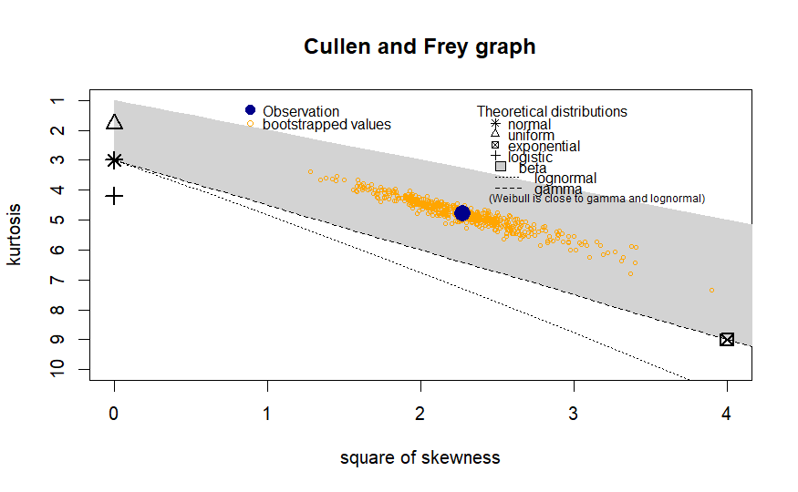

```r
# creating a skew vs. kurtois graph for walking 1986

descdist(walking_1986$DURATION %>% unlist() %>% as.numeric(), discrete=FALSE, boot=500)
```

As shown in the Cullen and Frey graph, we see that Weibull, gamma and exponential will likely be the best fit according to the graph above. Then we compare these models to find the best model.

```r
# Based on the skew vs. kurtois graph the best distribution

#Calculating gamma distribution

gamma_w_1986_ <- fitdistrplus::fitdist(data=walking_1986$DURATION%>% unlist() %>% as.numeric(), "gamma", method="mle", optim.method="Nelder-Mead", weights = round(walking_1986$WGHT_EPI))
fit_dgamma <- data.frame(f = dgamma(walking_1986$DURATION, shape = gamma_w_1986_$estimate[1], rate = gamma_w_1986_$estimate[2]), x = walking_1986$DURATION, type = "Gamma")

summary(gamma_w_1986_)
```

```
Fitting of the distribution ' gamma ' by maximum likelihood
Parameters :
```

|  | estimate | Std. Error |
| --- | --- | --- |
| shape | 1.61631569 | 2.384989e-05 |
| rate | 0.06898165 | 1.190783e-06 |

```
Loglikelihood:  -31484327843   AIC:  62968655691   BIC:  62968655699
Correlation matrix:
          shape      rate
shape 1.0000000 0.8544939
rate  0.8544939 1.0000000
```

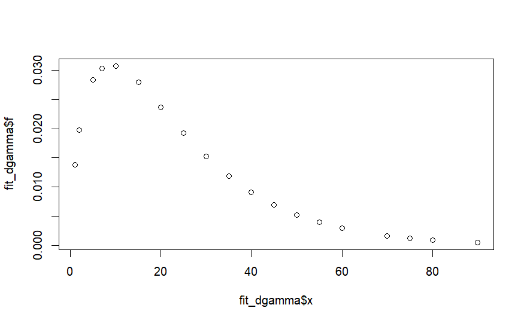

```r
plot(x= fit_dgamma$x, y=fit_dgamma$f)
```

```r
#Calculating weibull distribution
exp_w_1986_ <- fitdistrplus::fitdist(data=walking_1986$DURATION%>% unlist() %>% as.numeric(), "exp", method="mle", optim.method="Nelder-Mead", weights = round(walking_1986$WGHT_EPI))
summary(exp_w_1986_)
```

```
Fitting of the distribution ' exp ' by maximum likelihood
Parameters :
```

|  | estimate | Std. Error |
| --- | --- | --- |
| rate | 0.04267241 | 4.863123e-07 |

```
Loglikelihood:  -31949475691   AIC:  63898951384   BIC:  63898951388
```

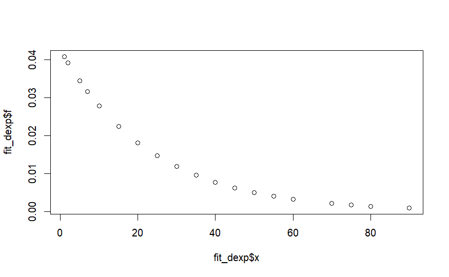

```r
fit_dexp <- data.frame(f = dexp(walking_1986$DURATION, rate = exp_w_1986_$estimate[1]), x = walking_1986$DURATION, type = "exp")

plot(x= fit_dexp$x, y=fit_dexp$f)
```

Now let’s compare these models based on AIC and BIC to see which fits the walk data best:

```r
#comparing these models AIC and BIC to see which fits the walk data best:
broom::glance(MASS::fitdistr(walking_1986$DURATION%>% unlist() %>% as.numeric(),"gamma"))
```

| logLik | AIC | BIC | nobs |
| --- | --- | --- | --- |
| -1574.499 | 3152.998 | 3160.899 | 384 |

```r
broom::glance(MASS::fitdistr(walking_1986$DURATION%>% unlist() %>% as.numeric(),"exponential"))
```

| logLik | AIC | BIC | nobs |
| --- | --- | --- | --- |
| -1597.308 | 3196.616 | 3200.567 | 384 |

```r
NA
```

```r
walking_1986_gamma<- gamma_w_1986_
walking_1986 <- walking_1986 %>%
 mutate(f = dgamma(DURATION, walking_1986_gamma$estimate["shape"], walking_1986_gamma$estimate["rate"] ))
summary(walking_1986$f)
```

```
     Min.   1st Qu.    Median      Mean   3rd Qu.      Max.
0.0004777 0.0152267 0.0279544 0.0214802 0.0283124 0.0307408
```

### Destination : Home (1)- 1986

using a skew vs. kurtois graph to descriptive statistics of data

```
summary statistics
------
min:  1   max:  90
median:  15
mean:  23.28144
estimated sd:  19.20589
estimated skewness:  1.42372
estimated kurtosis:  4.438005
```

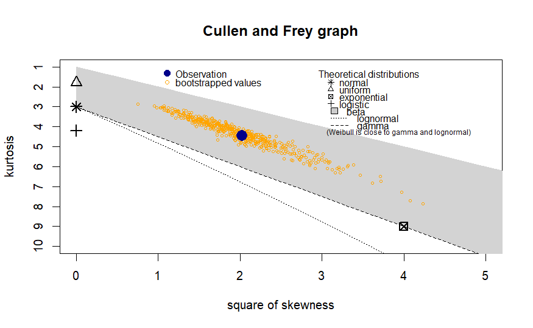

```r
# creating a skew vs. kurtois graph for walking 1986

# Filter the data based on the "destination" column
 w_1_1986 <- walking_1986 %>%
  filter(destination == "1")
descdist(w_1_1986$DURATION %>% unlist() %>% as.numeric(), discrete=FALSE, boot=500)
```

As shown in the Cullen and Frey graph, we see that gamma and exponential will likely be the best fit according to the graph above. Then we compare these models to find the best model.

```r
# Based on the skew vs. kurtois graph the best distribution

#Calculating gamma distribution
gamma_w1_1986_ <- fitdistrplus::fitdist(data=w_1_1986$DURATION%>% unlist() %>% as.numeric(), "gamma", method="mle", optim.method="Nelder-Mead", weights = round(w_1_1986$WGHT_EPI))
fit_dgamma_w186 <- data.frame(f = dgamma(w_1_1986$DURATION, shape = gamma_w1_1986_$estimate[1], rate = gamma_w1_1986_$estimate[2]), x = w_1_1986$DURATION, type = "Gamma")

summary(gamma_w1_1986_)
```

```
Fitting of the distribution ' gamma ' by maximum likelihood
Parameters :
```

|  | estimate | Std. Error |
| --- | --- | --- |
| shape | 1.68466553 | 3.735636e-05 |
| rate | 0.07215849 | 1.860210e-06 |

```
Loglikelihood:  -13978362180   AIC:  27956724364   BIC:  27956724370
Correlation matrix:
         shape     rate
shape 1.000000 0.859879
rate  0.859879 1.000000
```

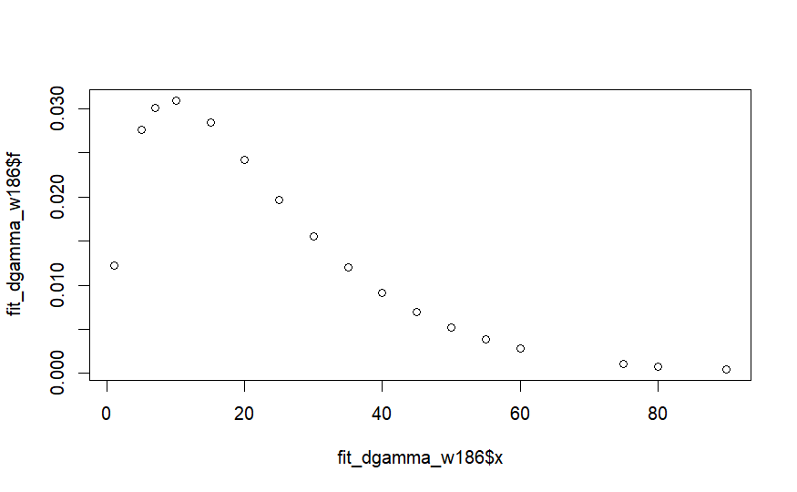

```r
plot(x= fit_dgamma_w186$x, y=fit_dgamma_w186$f)
```

```r
#Calculating exponential distribution
exp_w1_1986_ <- fitdistrplus::fitdist(data=w_1_1986$DURATION%>% unlist() %>% as.numeric(), "exp", method="mle", optim.method="Nelder-Mead", weights = round(w_1_1986$WGHT_EPI))
summary(exp_w1_1986_)
```

```
Fitting of the distribution ' exp ' by maximum likelihood
Parameters :
```

|  | estimate | Std. Error |
| --- | --- | --- |
| rate | 0.04281845 | 7.311434e-07 |

```
Loglikelihood:  -14219300260   AIC:  28438600523   BIC:  28438600526
```

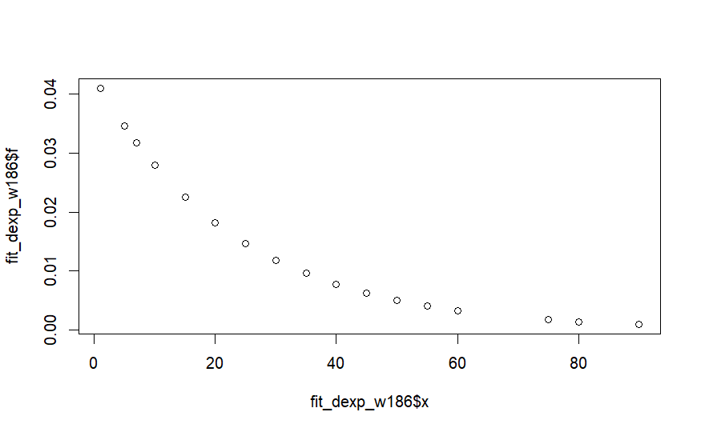

```r
fit_dexp_w186 <- data.frame(f = dexp(w_1_1986$DURATION, rate = exp_w1_1986_$estimate[1]),
                       x = w_1_1986$DURATION, type = "exp")

plot(x = fit_dexp_w186$x, y = fit_dexp_w186$f)
```

Now let’s compare these models AIC and BIC to see which fits the walk data best:

```r
#comparing these models AIC and BIC to see which fits the walk data best:
broom::glance(MASS::fitdistr(w_1_1986$DURATION%>% unlist() %>% as.numeric(),"gamma"))
```

| logLik | AIC | BIC | nobs |
| --- | --- | --- | --- |
| -679.7006 | 1363.401 | 1369.637 | 167 |

```r
broom::glance(MASS::fitdistr(w_1_1986$DURATION%>% unlist() %>% as.numeric(),"exponential"))
```

| logLik | AIC | BIC | nobs |
| --- | --- | --- | --- |
| -692.6586 | 1387.317 | 1390.435 | 167 |

So, gamma has largest logLik and the smallest AIC and BIC. we will pick gamma function for walking trips in 1986!

```r
walking_186_gamma <- gamma_w1_1986_
w_1_1986 <- w_1_1986 %>%
 mutate(f_1 = dgamma(DURATION, walking_186_gamma$estimate["shape"], walking_186_gamma$estimate["rate"]))
summary(w_1_1986$f_1)
```

```
     Min.   1st Qu.    Median      Mean   3rd Qu.      Max.
0.0004336 0.0155148 0.0276327 0.0218021 0.0284913 0.0309627
```

### Destination : Work place (2)- 1986

using a skew vs. kurtois graph to descriptive statistics of data

```
summary statistics
------
min:  5   max:  90
median:  20
mean:  30.26786
estimated sd:  24.8892
estimated skewness:  1.091452
estimated kurtosis:  3.278776
```

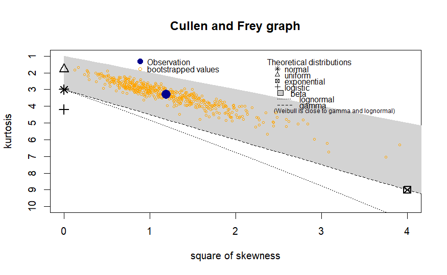

```r
# creating a skew vs. kurtois graph for walking 1986

# Filter the data based on the "destination" column
 w_2_1986 <- walking_1986 %>%
  filter(destination == "2")
descdist(w_2_1986$DURATION %>% unlist() %>% as.numeric(), discrete=FALSE, boot=500)
```

As shown in the Cullen and Frey graph, we see that gamma and exponential will likely be the best fit according to the graph above. Then we compare these models to find the best model.

```r
# Based on the skew vs. kurtois graph the best distribution

#Calculating gamma distribution
gamma_w2_1986_ <- fitdistrplus::fitdist(data=w_2_1986$DURATION%>% unlist() %>% as.numeric(), "gamma", method="mle", optim.method="Nelder-Mead", weights = round(w_2_1986$WGHT_EPI))
fit_dgamma_w286 <- data.frame(f = dgamma(w_2_1986$DURATION, shape = gamma_w2_1986_$estimate[1], rate = gamma_w2_1986_$estimate[2]), x = w_2_1986$DURATION, type = "Gamma")

summary(gamma_w2_1986_)
```

```
Fitting of the distribution ' gamma ' by maximum likelihood
Parameters :
```

|  | estimate | Std. Error |
| --- | --- | --- |
| shape | 1.55595047 | 5.428973e-05 |
| rate | 0.05309877 | 2.180101e-06 |

```
Loglikelihood:  -5914428110   AIC:  11828856223   BIC:  11828856227
Correlation matrix:
          shape      rate
shape 1.0000000 0.8493227
rate  0.8493227 1.0000000
```

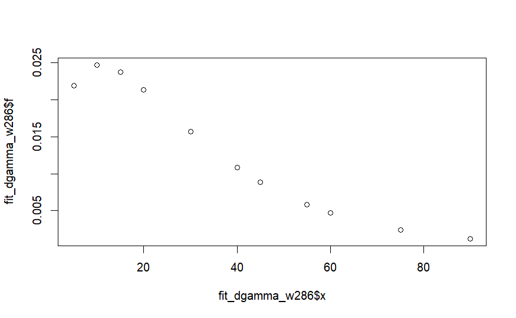

```r
plot(x= fit_dgamma_w286$x, y=fit_dgamma_w286$f)
```

```r
#Calculating exponential distribution
exp_w2_1986_ <- fitdistrplus::fitdist(data=w_2_1986$DURATION%>% unlist() %>% as.numeric(), "exp", method="mle", optim.method="Nelder-Mead", weights = round(w_2_1986$WGHT_EPI))
summary(exp_w2_1986_)
```

```
Fitting of the distribution ' exp ' by maximum likelihood
Parameters :
```

|  | estimate | Std. Error |
| --- | --- | --- |
| rate | 0.03412242 | 9.220209e-07 |

```
Loglikelihood:  -5985662297   AIC:  11971324596   BIC:  11971324598
```

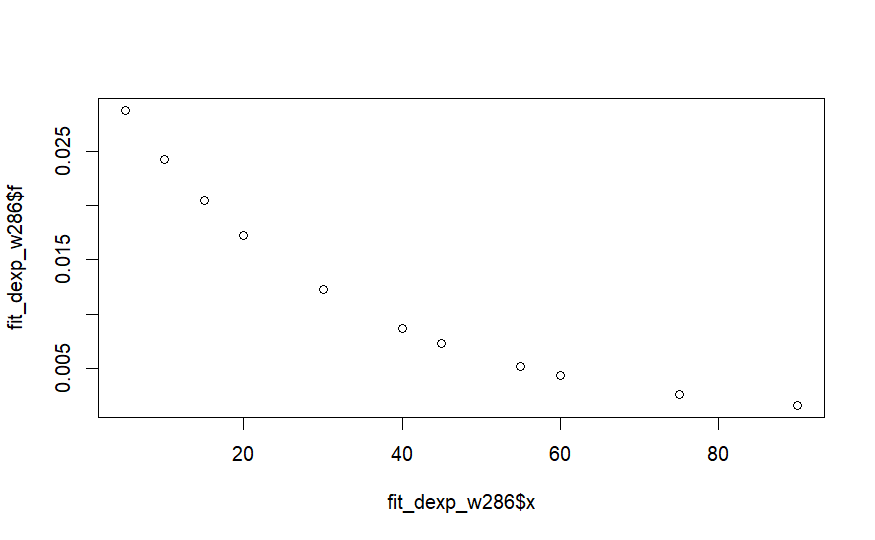

```r
fit_dexp_w286 <- data.frame(f = dexp(w_2_1986$DURATION, rate = exp_w2_1986_$estimate[1]),
                       x = w_2_1986$DURATION, type = "exp")

plot(x = fit_dexp_w286$x, y = fit_dexp_w286$f)
```

Now let’s compare these models AIC and BIC to see which fits the walk data best:

```r
#comparing these models AIC and BIC to see which fits the walk data best:
broom::glance(MASS::fitdistr(w_2_1986$DURATION%>% unlist() %>% as.numeric(),"gamma"))
```

| logLik | AIC | BIC | nobs |
| --- | --- | --- | --- |
| -243.9778 | 491.9556 | 496.0063 | 56 |

```r
broom::glance(MASS::fitdistr(w_2_1986$DURATION%>% unlist() %>% as.numeric(),"exponential"))
```

| logLik | AIC | BIC | nobs |
| --- | --- | --- | --- |
| -246.9648 | 495.9297 | 497.955 | 56 |

So, gamma has largest logLik and the smallest AIC and BIC. we will pick gamma function for walking trips in 1986!

```r
walking_286_gamma <- gamma_w2_1986_
w_2_1986 <- w_2_1986 %>%
 mutate(f_2 = dgamma(DURATION, walking_286_gamma$estimate["shape"], walking_286_gamma$estimate["rate"]))
summary(w_2_1986$f_2)
```

```
    Min.  1st Qu.   Median     Mean  3rd Qu.     Max.
0.001197 0.008884 0.021347 0.016487 0.023723 0.024694
```

using a skew vs. kurtois graph to descriptive statistics of data

```
summary statistics
------
min:  1   max:  90
median:  15
mean:  21.52174
estimated sd:  19.15988
estimated skewness:  1.748488
estimated kurtosis:  6.011599
```

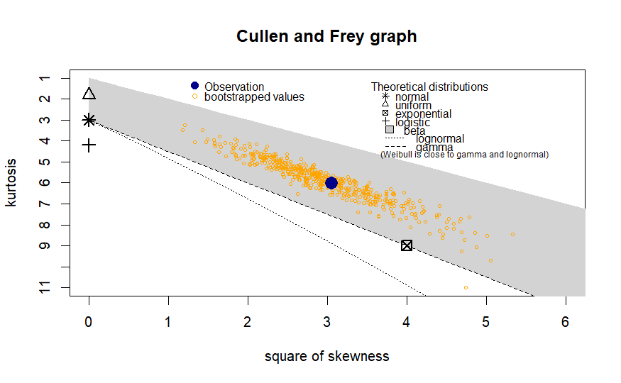

```r
# creating a skew vs. kurtois graph for walking 1986

# Filter the data based on the "destination" column
 w_3_1986 <- walking_1986 %>%
  filter(destination == "3")
descdist(w_3_1986$DURATION %>% unlist() %>% as.numeric(), discrete=FALSE, boot=500)
```

As shown in the Cullen and Frey graph, we see that gamma, weibull and exponential will likely be the best fit according to the graph above. Then we compare these models to find the best model.

```r
# Based on the skew vs. kurtois graph the best distribution

#Calculating gamma distribution
gamma_w3_1986_ <- fitdistrplus::fitdist(data=w_3_1986$DURATION%>% unlist() %>% as.numeric(), "gamma", method="mle", optim.method="Nelder-Mead", weights = round(w_3_1986$WGHT_EPI))
fit_dgamma_w386 <- data.frame(f = dgamma(w_3_1986$DURATION, shape = gamma_w3_1986_$estimate[1], rate = gamma_w3_1986_$estimate[2]), x = w_3_1986$DURATION, type = "Gamma")

summary(gamma_w3_1986_)
```

```
Fitting of the distribution ' gamma ' by maximum likelihood
Parameters :
```

|  | estimate | Std. Error |
| --- | --- | --- |
| shape | 1.65469497 | 3.984759e-05 |
| rate | 0.07970931 | 2.237687e-06 |

```
Loglikelihood:  -11496010502   AIC:  22992021009   BIC:  22992021015
Correlation matrix:
          shape      rate
shape 1.0000000 0.8575901
rate  0.8575901 1.0000000
```

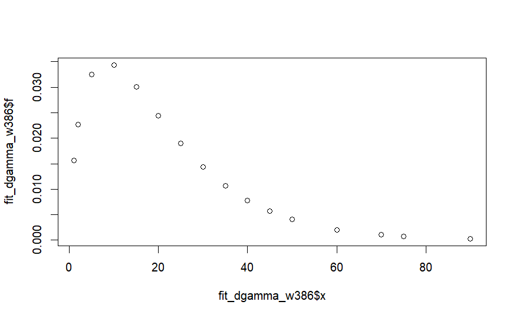

```r
plot(x= fit_dgamma_w386$x, y=fit_dgamma_w386$f)
```

```r
#Calculating exponential distribution
exp_w3_1986_ <- fitdistrplus::fitdist(data=w_3_1986$DURATION%>% unlist() %>% as.numeric(), "exp", method="mle", optim.method="Nelder-Mead", weights = round(w_3_1986$WGHT_EPI))
summary(exp_w3_1986_)
```

```
Fitting of the distribution ' exp ' by maximum likelihood
Parameters :
```

|  | estimate | Std. Error |
| --- | --- | --- |
| rate | 0.04817077 | 8.944559e-07 |

```
Loglikelihood:  -11687165069   AIC:  23374330139   BIC:  23374330142
```

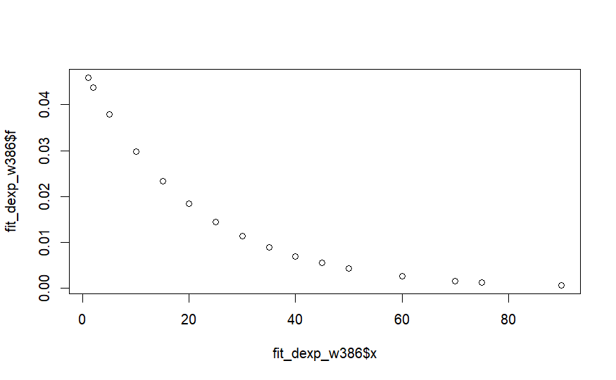

```r
fit_dexp_w386 <- data.frame(f = dexp(w_3_1986$DURATION, rate = exp_w3_1986_$estimate[1]),
                       x = w_3_1986$DURATION, type = "exp")

plot(x = fit_dexp_w386$x, y = fit_dexp_w386$f)
```

Now let’s compare these models AIC and BIC to see which fits the walk data best:

```r
#comparing these models AIC and BIC to see which fits the walk data best:
broom::glance(MASS::fitdistr(w_3_1986$DURATION%>% unlist() %>% as.numeric(),"gamma"))
```

| logLik | AIC | BIC | nobs |
| --- | --- | --- | --- |
| -646.3749 | 1296.75 | 1302.913 | 161 |

```r
broom::glance(MASS::fitdistr(w_3_1986$DURATION%>% unlist() %>% as.numeric(),"exponential"))
```

| logLik | AIC | BIC | nobs |
| --- | --- | --- | --- |
| -655.1192 | 1312.238 | 1315.32 | 161 |

So, gamma has largest logLik and the smallest AIC and BIC. we will pick gamma function for walking trips in 1986!

```r
walking_386_gamma <- gamma_w3_1986_
w_3_1986 <- w_3_1986 %>%
 mutate(f_3 = dgamma(DURATION, walking_386_gamma$estimate["shape"], walking_386_gamma$estimate["rate"]))
summary(w_3_1986$f_3)
```

```
     Min.   1st Qu.    Median      Mean   3rd Qu.      Max.
0.0002463 0.0143295 0.0300890 0.0240312 0.0325246 0.0343723
```

creating a new walking data frame that have all the f values for walking 1986

```r
walking_1986_f <- bind_rows(w_1_1986, w_2_1986, w_3_1986)
```